# Práctica 6. Análisis Exploratorio de Datos.

Tratamiento de Datos, Grado en Ciencia de Datos - UV

Carlos Santiago Martinez Torres

# Introducción y objetivos

El objetivo de esta práctica es realizar un análisis exploratorio de datos: explorando el conjunto de datos; obteniendo los estadísticos básicos de las variables numéricas; visualizando las relaciones entre variables; y calculando las relaciones entre variables tanto numéricas como categóricas.

En esta práctica, las etapas que vamos a considerar en el análisis exploratorio de datos son:

1. Lectura e inspección de los datos.
2. Análisis univariante de los datos: variables numéricas y categóricas.
3. Análisis bivariante de los datos: variables numéricas y categóricas.

# Lectura e inspección de los datos

Vamos a trabajar con el conjunto de datos “Nos Autoevaluamos” generado por nosotros al rellenar la tabla de datos de la tarea correspondiente.

Este conjunto contiene datos perdidos e inconsistencias que habrá que corregir antes de analizar la distribución de los datos. Para evitar estas inconsistencias, estos datos deberán ser eliminados, corregidos o imputados, tal y como vimos en la práctica anterior.

El conjunto “`NosAutoanalizamos_TD2019 - Hoja 1 - Clean.tsv`” ya ha sido procesado en parte para poder trabajar en esta práctica. En él tenemos para cada una de las asignaturas (ALG, ANM, FP, DCS y MD) columnas acabadas en `.num`, con las notas en valor numérico, y columnas acabadas en `.cat`, con valores categóricos: AP para aprobada, NP para no presentado y NC para no compensable.

| Variable | Comentarios |
| --- | --- |
| Identificación | Usuario de correo |
| Age | Edad en años |
| Sex | Sexo: ‘Femenino’, ‘Masculino’ |
| Wr.Hnd | Distancia del extremo del índice al extremo del pulgar en centímetros de la mano con la que escribimos |
| NW.Hnd | Mano con la que escribes: ‘Izquierda’, ‘Derecha’ |
| Fold | Brazo que está arriba cuando cruzas los brazos: ‘Izquierdo’, ‘Derecho’ |
| Pulse | Ritmo cardíaco, en reposo, en latidos por minuto. |
| Clap | Posición de las manos al aplaudir: ‘Der s Izd’, (Derecha sobre izquierda) ‘Izq s Der’, ‘Ninguna’ |
| Exer | Días a la semana que realizas ejercicio físico: Numérica de 0-7 |
| Smoke | Fumador: ‘Sí’ / ‘No’ |
| Height | Altura expresada en centímetros |
| ALG | Calificación obtenida en álgebra. Usa ‘NP’ para no presentado y ‘NC’, para no compensable, si procede |
| ANM | Calificación obtenida en análisis matemático. Usa ‘NP’ para no presentado y ‘NC’, para no compensable, si procede |
| FP | Calificación obtenida en fundamentos de programación. Usa ‘NP’ para no presentado y ‘NC’, para no compensable, si procede |
| DCS | Calificación obtenida en Datos Ciencia y Sociedad. Usa ‘NP’ para no presentado y ‘NC’, para no compensable, si procede |
| MD | Calificación obtenida en Matemática Discreta. Usa ‘NP’ para no presentado y ‘NC’, para no compensable, si procede |
| HSt | Horas de trabajo diarias relacionadas con los estudios, además de la asistencia a clase |
| Hwork | Horas de trabajo remunerado semanales (0 indica que no tiene otro trabajo) |
| Comentarios | Campo de texto libre para incluir comentarios que consideres sobre la asignatura |

## Ejercicio 1: Lectura de datos

- Lee los datos del fichero con `read_tsv` a una variable llamada `Datos`.
- Convierte las variables categóricas acabadas en `.cat` a tipo `factor`. Puedes hacerlo:
- Usando la función `mutate_at` (junto con `vars`, `ends_with` y `as.factor`).
- Usando `mutate(across())` (junto con `ends_with` y `as.factor`).

```r
fichero <- 'data/NosAutoanalizamos_TD2019 - Hoja 1 - Clean.tsv'
Datos <- read_tsv(fichero)

Datos <- Datos %>%
  mutate(across(.cols = ends_with('.cat'),
                .fns = ~ as.factor(.)))
```

## Ejercicio 2: Inspección visual

Inspecciona visualmente los valores del conjunto de datos (`View`) y ordena de mayor a menor y de menor a mayor cada variable.

```r
# Datos %>%
#   arrange(desc(Age)) %>%
#   View()

# Datos %>%
#   arrange(Wr.Hnd) %>%
#   View()
```

En las variables vistas, *Age* y *Wr.Hnd*, vemos que la edad máxima es 37 y la mínima es 18, y la distancia máxima en centímetros con la mano con que se escribe es de 22 y la mínima de 12.5.

Para ver las demás variables, solo cambiamos el argumento dentro de *arrange()*.

# Análisis univariante de variables numéricas

## Ejercicio 3: Estadísticos básicos

Empleando la función `sumarise(across())` calcula la media, la desviación típica, mediana y el *interquartile range* (`IQR`) de las variables que acaban en `.num` (notas numéricas).

- Ten en cuenta que no se puede realizar un análisis estadístico con datos faltantes, pero en la mayoría de los casos se puede optar por no considerar dichos valores al realizar los cálculos (`na.rm=TRUE`).
- Reordena los resultados para generar una tabla en la que tengas en cada fila una de las variables y en cada columna los estadísticos calculados.
  1. Primero usa `pivot_longer` para juntar todo en dos columnas, una para los nombres combinados de las variables y sus estadísticos, y otra para los valores.
  2. Luego usa `separate` para separar la columna de nombres en dos, una llamada `asignatura` con el nombre de la variable, y otra llamada `stat` con el nombre del estadístico.
  3. Por último, usa `pivot_wider` para distribuir la columna `stat` en cuatro columnas, cada una con el nombre del estadístico.
  4. Por último, combina las columnas que almacenan media y desviación típica en una columna, tipo texto, `mean`±`sd`.

*Expresa los resultados con 2 decimales*.

El resultado final debe ser una tabla como ésta:

| asignatura | mean±sd | median | IQR |
| --- | --- | --- | --- |
| ALG.num |  |  |  |
| ANM.num |  |  |  |
| etc |  |  |  |

```r
# Estadísticos de todas las columnas numéricas:
funs_apply = list("mean"= mean, "sd"=sd, "median"=median, "IQR"=IQR)

est_bsc <- Datos %>%
  # Estadisticos
  summarise(across(.cols = ends_with('.num'),
                   .fns = funs_apply,
                   na.rm = TRUE)) %>%
  # Juntar en dos columnas
  pivot_longer(cols = everything(),
               names_to = 'asignatura',
               values_to = 'valor') %>%
  # Separar columna de nombres
  separate(asignatura, into = c('asignatura', 'stat'), sep = '_') %>%
  # Usar pivot_wider para distribuir columna
  pivot_wider(names_from = stat, values_from = valor) %>%
  # Combinar columnas
  mutate('mean±sd' = mean+sd) %>%
  select(asignatura, 'mean±sd', median, IQR)

kable(est_bsc)
```

| asignatura | mean±sd | median | IQR |
| --- | --- | --- | --- |
| ALG.num | 7.543146 | 6.00 | 4.00 |
| ANM.num | 8.557142 | 6.70 | 2.50 |
| DCS.num | 8.763241 | 7.40 | 1.85 |
| FP.num | 8.570562 | 6.90 | 3.82 |
| MD.num | 7.735653 | 6.05 | 2.25 |

## Ejercicio 4: Distribución de datos

Representa gráficamente la curva de notas de la asignatura DCS estimando la distribución de datos: histograma (`geom_histogram`) y curva de densidad (`geom_density`).

- Recuerda que para que los dos representaciones ‘casen’ hay que indicarle a `geom_histogram` que use la función `density` para estimar el histograma, es decir: `geom_histogram(aes(y=stat(density)))`.
- Compara el resultado con la media de las notas para esa asignatura. Puedes marcar dicha media en el gráfico con `geom_point` o con `geom_vline()` especificando el parámetro `xintercept`.

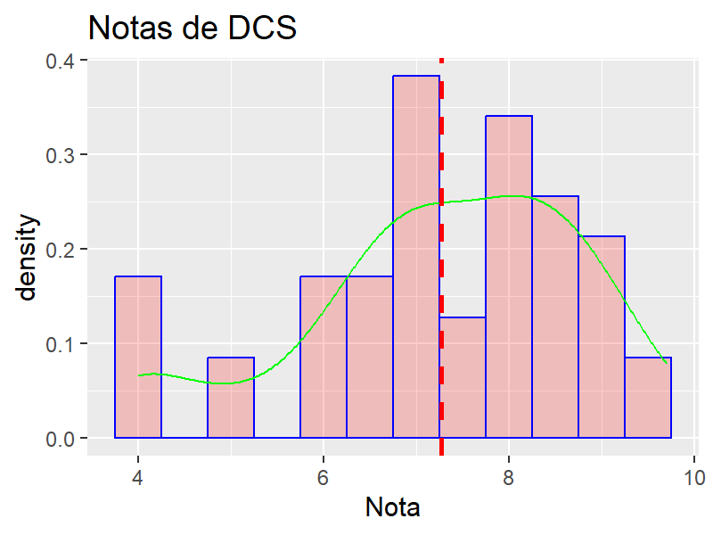

```r
ggplot(data = Datos, aes(x=DCS.num)) +
  geom_histogram(aes(y = stat(density)),
                 binwidth = 0.5,
                 col = 'blue',
                 fill = 'red',
                 alpha = 0.2, # Transparente 100% = 0
                 na.rm=TRUE) +
  geom_density(col='green') +
  geom_vline(xintercept = mean(Datos$DCS.num, na.rm = TRUE),
             col = 'red',
             linetype = 'dashed',
             linewidth = 1) +
  labs(title = 'Notas de DCS',
       x = 'Nota')
```

## Ejercicio 5: Test de normalidad de la distribución de datos

Compara la distribución de probabilidad de las notas de la asignatura DCS con la de una Gaussiana empleando la función `qqPlot` (quantile-quantile plot) de la librería `car`, que representa gráficamente los cuantiles de la distribución analizada respecto de los de una distribución normal (Gaussiana).

Si los datos fueran normales (siguieran una distribución Gaussiana), los puntos seguirían la linea azul. Adicional, la curva hacia arriba, indica valores extremos mayores, mientras que la curva hacia abajo, valores extremos menores.

Permite identificar *Outliers* dentro de los datos. Por ejemplo, ha devuelto que los registros 18 y 19, tienen notas muy bajas (4.0), que se pueden considerar como valores atípicos.

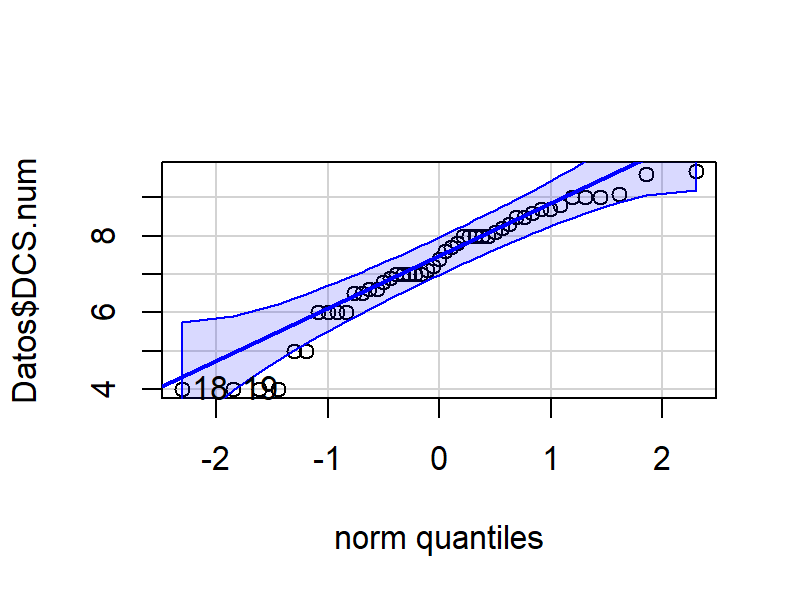

```
[1] 18 19
```

```r
library(car)

qqPlot(x = Datos$DCS.num)
```

# Análisis univariante de variables categóricas

## Ejercicio 6: Análisis de frecuencias en variables categóricas

Vamos a calcular la frecuencia de cada valor en las variables categóricas de calificaciones con la función `table`.

- Calcula la frecuencia de cada calificación para la asignatura MD.
- Usa también la función `table` para calcular la tabla de contingencia con la frecuencia de cada combinación de las calificaciones de las asignaturas MD y ANM.
- Representa la tabla de contingencia usando `mosaicplot`.

```r
Datos %>%
  select(MD.cat) %>%
  table()
```

```
MD.cat
AP NC NP
44  1  3
```

```r
Datos %>%
  select(MD.cat, ANM.cat) %>%
  table()
```

```
      ANM.cat
MD.cat AP NC NP
    AP 42  1  1
    NC  1  0  0
    NP  0  0  3
```

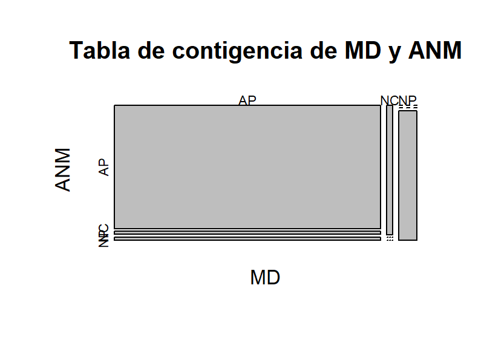

```r
Datos %>%
  select(MD.cat, ANM.cat) %>%
  table() %>%
  mosaicplot(main = 'Tabla de contigencia de MD y ANM',
             ylab = 'ANM',
             xlab = 'MD')
```